# Prueba_R5

José Rubén Niño Quevedo

2023-07-13

## DESCRIPCIÓN DE LA PRUEBA

Esta prueba que está diseñada para medir tus capacidades como Ingeniero de Datos. Porfavor, envíanos como respuesta este correo un repositorio de GitHub (asegurate de dejarlo público) con todos los entregables y demás cosas que quieras sumarle al ejercicio y que creas que nos ayuden a tomar una decisión.

Para realizarla debes utilizar este dataset: https://docs.google.com/spreadsheets/d/17TUqLPowoHFiu6PGmHHs6oX5jTpz3C5N6vJ014eUOwA/edit#gid=913663848

1. Diseñar un DWH con base en el dataset, se puede usar cualquier metodología.

Entregable: Gráfico representando el diseño, explicación de por qué se eligió la metodología teniendo en cuenta la escalabilidad y facilidad de uso para usuarios finales.

2. Crear un pipeline en Python que tome como input el dataset y que escriba el resultado en las tablas diseñadas en el punto 1. Se puede usar cualquier motor de base de datos.

Entregable: Código en Python del pipeline, se puede usar cualquier librería que considere necesaria.

3. Una vez los datos estén cargados a la base de datos utilice Python y SQL para responder las siguientes preguntas:
1. ¿Cuáles son las tiendas con compras de al menos 100 clientes diferentes?
2. ¿Cuáles son los 5 barrios donde la mayor cantidad de clientes únicos realizan compras en tiendas tipo ‘Tienda Regional’?

Entregable: Código en Python y SQL resolviendo cada una de las preguntas.

## SOLUCIÓN PROPUESTA

La siguiente es una propuesta de solución para la tarea solicitada. este documento ha sido elaborado en R Markdown.

### Diseño del Data Warehouse (DWH):

Para el diseño del DWH basado en el dataset proporcionado, se propone la siguiente estructura:

**Tabla “Clientes”:** num_documento_cliente (clave primaria), tipo_documento_cliente, id_barrio (clave foránea).

**Tabla “Tiendas”:** codigo_tienda (clave primaria), tipo_tienda, latitud_tienda, longitud_tienda, id_barrio (clave foránea).

**Tabla “Compras”:** id_compra (clave primaria), num_documento_cliente (clave foránea), codigo_tienda (clave foránea), total_compra, fecha_compra.

**Tabla “Barrios”:** id_barrio (clave primaria), nombre_barrio.

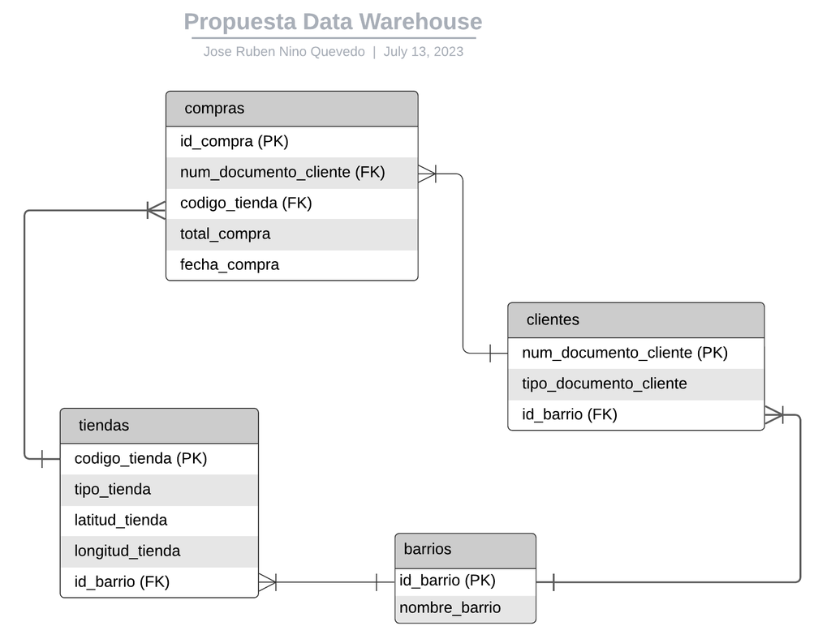

En resumen, el diseño propuesto proporciona una estructura simple y comprensible para los usuarios finales, al tiempo que permite un rendimiento eficiente y escalabilidad para futuras necesidades analíticas.

### Pipeline en Python usando el motor de base de datos MySQL

El siguiente código en Python utiliza el motor de base de datos MySQL para crear un pipeline que toma el dataset como entrada y escribe los resultados en las tablas diseñadas en el punto anterior.

```r
library(reticulate)
use_python("C:/Users/dell/AppData/Local/Programs/Python/Python311")
```

```python
import pandas as pd
from sqlalchemy import create_engine

# Paso 1: Leer el conjunto de datos
df = pd.read_csv("C:/Users/dell/Downloads/Prueba_Tecnica_R5/dataset.csv")

# Paso 2: Conectarse a la base de datos MySQL
db_user = 'root'
db_password = 'Rvb3nch0'
db_host = 'localhost'
db_name = 'jrnq_prueba_r5'

engine = create_engine(f'mysql+pymysql://{db_user}:{db_password}@{db_host}/{db_name}')

# Paso 3: Escribir los datos en las tablas

# Compras (fact)
df_fact = df[['num_documento_cliente', 'codigo_tienda', 'fecha_compra', 'total_compra']]
df_fact.to_sql('compras', con = engine, if_exists = 'replace', index=False)
```

```
## 94610
```

```python
# Tabla Tiendas (dim1)
df_dim1 = df[['codigo_tienda', 'tipo_tienda', 'latitud_tienda', 'longitud_tienda', 'id_barrio']]
df_dim1 = df_dim1.drop_duplicates()  # Eliminar duplicados si es necesario
df_dim1.to_sql('tiendas', con = engine, if_exists = 'replace', index=False)
```

```
## 6016
```

```python
# Tabla Barrios (dim2)
df_dim2 = df[['id_barrio', 'nombre_barrio']]
df_dim2 = df_dim2.drop_duplicates()  # Eliminar duplicados si es necesario
df_dim2.to_sql('barrios', con = engine, if_exists = 'replace', index=False)
```

```
## 277
```

```python
# Tabla Clientes (dim3)
df_dim3 = df[['num_documento_cliente', 'tipo_documento_cliente', 'id_barrio']]
df_dim3 = df_dim3.drop_duplicates()  # Eliminar duplicados si es necesario
df_dim3.to_sql('clientes', con = engine, if_exists = 'replace', index=False)
```

```
## 61370
```

```python
# Paso 4: Cerrar la conexión a la base de datos
engine.dispose()

print("¡Datos cargados exitosamente en las tablas del Data Warehouse!")
```

```
## ¡Datos cargados exitosamente en las tablas del Data Warehouse!
```

Este pipeline leerá el archivo CSV que contiene el dataset, establecerá una conexión con la base de datos MySQL utilizando SQLAlchemy y luego cargará los datos en las tablas correspondientes usando el método to_sql(). Al finalizar, se cerrará la conexión con la base de datos y se mostrará un mensaje de confirmación.

### ¿Cuáles son las tiendas con compras de al menos 100 clientes diferentes? y

El siguiente código, en Python y SQL, nos dará la respuesta a la pregunta dada:

```python
import pandas as pd
from sqlalchemy import create_engine

# Establecer la conexión con la base de datos MySQL
db_user = 'root'
db_password = 'Rvb3nch0'
db_host = 'localhost'
db_name = 'jrnq_prueba_r5'

engine = create_engine(f'mysql+pymysql://{db_user}:{db_password}@{db_host}/{db_name}')

# Consulta SQL
query = '''
    SELECT codigo_tienda, COUNT(DISTINCT num_documento_cliente) AS num_clientes
    FROM compras
    GROUP BY codigo_tienda
    HAVING COUNT(DISTINCT num_documento_cliente) >= 100;
'''

# Ejecutar la consulta y obtener los resultados en un DataFrame
df_result = pd.read_sql(query, con=engine)

# Cerrar la conexión a la base de datos
engine.dispose()

# Imprimir los resultados
print("Tiendas con compras de al menos 100 clientes diferentes:")
```

```
## Tiendas con compras de al menos 100 clientes diferentes:
```

```python
print(df_result)
```

```
##      codigo_tienda  num_clientes
## 0               60           351
## 1               61           191
## 2               62           142
## 3               64           179
## 4               77           184
## ..             ...           ...
## 249     1104427089           107
## 250     1121218306           189
## 251     1121218307           219
## 252     1121218308           154
## 253     1203621492           117
##
## [254 rows x 2 columns]
```

### ¿cuáles son los 5 barrios donde la mayor cantidad de clientes únicos realizan compras en tiendas tipo ‘Tienda Regional’?

Para responder a la preguntas utilizando Python y SQL con los datos ya cargados en la base de datos MySQL, podemos utilizar el siguiente código:

```python
import pandas as pd
from sqlalchemy import create_engine

# Establecer la conexión con la base de datos MySQL
db_user = 'root'
db_password = 'Rvb3nch0'
db_host = 'localhost'
db_name = 'jrnq_prueba_r5'

engine = create_engine(f'mysql+pymysql://{db_user}:{db_password}@{db_host}/{db_name}')

# Consulta SQL
query = '''
    SELECT b.nombre_barrio, COUNT(DISTINCT c.num_documento_cliente) AS num_clientes
    FROM compras AS c
    JOIN tiendas AS t ON c.codigo_tienda = t.codigo_tienda
    JOIN barrios AS b ON t.id_barrio = b.id_barrio
    WHERE t.tipo_tienda = 'Tienda Regional'
    GROUP BY b.nombre_barrio
    ORDER BY num_clientes DESC
    LIMIT 5
'''

# Ejecutar la consulta y obtener los resultados en un DataFrame
df_result = pd.read_sql(query, con=engine)

# Cerrar la conexión a la base de datos
engine.dispose()

# Imprimir los resultados
print("Los 5 barrios donde la mayor cantidad de clientes únicos realizan compras en tiendas tipo 'Tienda Regional':")
```

```
## Los 5 barrios donde la mayor cantidad de clientes únicos realizan compras en tiendas tipo 'Tienda Regional':
```

```python
print(df_result)
```

```
##                          nombre_barrio  num_clientes
## 0                       Unicentro Cali           363
## 1                            Versalles           331
## 2  Unidad Residencial Santiago de Cali           293
## 3                              El Sena           292
## 4                               Calima           253
```

En este código, se realiza una consulta SQL que une las tablas Compras, Tiendas y Barrios para obtener los barrios donde la mayor cantidad de clientes únicos realizan compras en tiendas de tipo ‘Tienda Regional’. Los resultados se ordenan por el número de clientes únicos en orden descendente y se limita a los 5 primeros resultados.

Claramente el código se puede modificar según las necesidades del usuario final.